# Probability Distributions

Yes, in theory any number of x is possible, die may be keep rooled to any number except 6 for 499 times.

10. Given that the probability mass function for the a geometric distributed random variable $X$ is
    $$P(X = x) = P( \overbrace{Fail, Fail,...,Fail}^{x-1}, Success) = qq...qp= q^{x-1}p$$
    Use the functions `dgeom()` and `pgeom()` to calculate the probabilites in question 8. For the `x` arguments, enter the outcomes `x-1` and your answer for #1 for the argument prob. (Hint: Check ?dgeom if you need help)

```r
# This is the theoretical probability for P(X=x) where x={1,...6}
theo6 <- dgeom((1:6)-1,1/6)
theo6
```

```
## [1] 0.16666667 0.13888889 0.11574074 0.09645062 0.08037551 0.06697960
```

```r
theo10<- dgeom((1:10)-1,1/6)
theo10
```

```
##  [1] 0.16666667 0.13888889 0.11574074 0.09645062 0.08037551 0.06697960
##  [7] 0.05581633 0.04651361 0.03876134 0.03230112
```

```r
# This is the theoretical probability for P(X>=7)
theo7plus <- pgeom(5, 1/6, lower.tail=FALSE)
theo7plus
```

```
## [1] 0.334898
```

11. Create a figure with two plots side by side: The first plot of the empirical probability mass function estimate based on the data simulated in #8 (histogram is acceptable - use `prob=TRUE`). The second plot should plot the theorical probability mass function for our data in #10.

```r
par(mfrow = c(1,2))
table(dataset)
```

```
## dataset
##   1   2   3   4   5   6   7   8   9  10  11  12  13  14  15  16  17  18  19  20
## 175 137 137  90  82  57  60  38  39  29  27  23  19  13  15   8   9   6  10   8
##  21  22  23  24  25  28  30  31  32  35  36  42
##   2   2   1   4   1   1   1   1   1   1   2   1
```

```r
plot1<-hist(dataset,xlim=c(0,50),ylim=c(0,0.2),breaks=(0:50),main="Histogram of question8",col='red',xlab="X",ylab="Empirical probability",prob=TRUE)

trytimesx<-c(1,2,3,4,5,6,7,8,9,10)
probx<-c(0.16666667,0.13888889,0.11574074,0.09645062,0.08037551,0.06697960,0.05581633,0.04651361,0.03876134,0.03230112)
dataq10<- data.frame(trytimesx,probx)
dataq10
```

```
##    trytimesx      probx
## 1          1 0.16666667
## 2          2 0.13888889
## 3          3 0.11574074
## 4          4 0.09645062
## 5          5 0.08037551
## 6          6 0.06697960
## 7          7 0.05581633
## 8          8 0.04651361
## 9          9 0.03876134
## 10        10 0.03230112
```

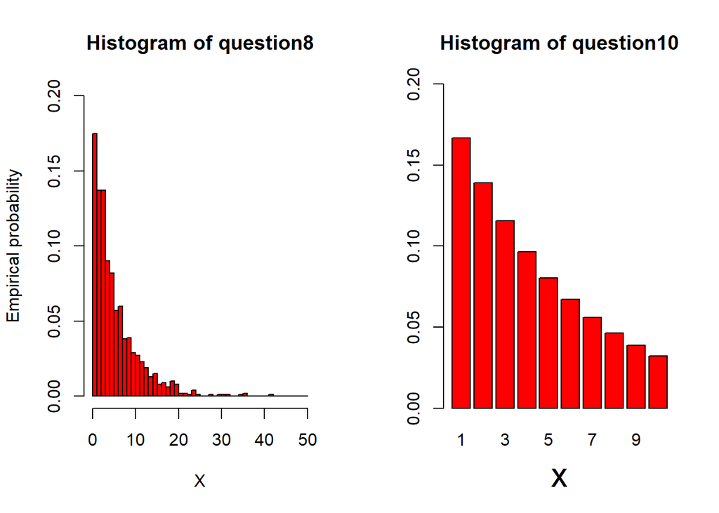

```r
barplot(height=dataq10$probx,names=dataq10$trytimesx,
        col="red",xlab="x",cex.lab=2,ylim=c(0,0.2),main="Histogram of question10")
```

12. How close are your answers from your simulation to the probabilities from the geometric distribution you just created? Describe this given what we’ve learned about the Weak Law of Large Numbers in lecture 8. What parameters need to change in our function in order for our empirical probabilities to match the theoretical values for $(X=x)$

```r
#I think very close,we just need to increase the number of trials to make our empirical probabilities to match the theretical values.maybe increase 1000 in Q8 to 100000
```

13. For $K$ = 6, and `n_sim` = [1 - 5000] (Hint: use a for loop) plot the mean of each sample as a line graph. Add a horizontal line at the theorical mean (6). What is your observation of this relationship between n_sim and the mean of our sample?

```r
n=c(1:500)
m<-c()
for (val in n){
  n<-nfact2(6,val)
  m<-c(m,mean(n))
}
m
```

```
##   [1] 3.000000 5.000000 3.333333 5.500000 2.600000 9.166667 9.000000 4.875000
##   [9] 6.888889 9.400000 4.727273 4.083333 6.230769 5.642857 7.466667 6.375000
##  [17] 5.588235 6.611111 7.157895 6.150000 4.761905 5.454545 8.869565 5.291667
##  [25] 6.480000 5.884615 5.222222 4.500000 6.310345 5.366667 5.741935 6.812500
##  [33] 5.878788 6.000000 5.914286 4.277778 5.756757 8.447368 4.948718 5.800000
##  [41] 7.048780 8.142857 6.093023 6.272727 6.466667 5.695652 6.893617 7.041667
##  [49] 6.816327 5.400000 4.549020 6.442308 6.207547 7.092593 6.327273 6.107143
##  [57] 6.631579 5.879310 6.135593 6.416667 5.295082 5.741935 5.555556 7.656250
##  [65] 5.646154 5.803030 4.985075 6.397059 5.231884 6.114286 6.352113 7.236111
##  [73] 6.534247 5.986486 6.933333 7.026316 5.636364 5.615385 6.518987 6.062500
##  [81] 6.950617 5.243902 7.048193 5.619048 5.811765 6.546512 6.103448 5.920455
##  [89] 7.078652 6.755556 5.879121 6.315217 5.473118 6.000000 5.905263 5.489583
##  [97] 5.402062 5.857143 5.323232 6.010000 5.297030 5.656863 5.601942 5.615385
## [105] 5.952381 5.452830 6.000000 5.574074 5.458716 5.518182 6.063063 6.366071
## [113] 5.867257 5.956140 7.226087 5.689655 5.350427 5.703390 5.369748 7.066667
```

[output cut: 48 more lines]

[figure not shown]

```r
t=1:500
plot(t,m,type="l",xlab="n_sim",ylab="mean of each sample",main="Mean of 5000 sample")
abline(h=6,col="red")
```

```r
# My obeservation is with n_sim keep increasing, the mean of each sample becomes closer to 6
```

14. For $K$ = 6, what is the probability that it takes more than 12 rolls to roll a 6?

```r
#11.2156%
pgeom(q = 11, prob = 1/6, lower.tail = FALSE)
```

```
## [1] 0.1121567
```

15. For $K$ = 6, what is the probability that you roll a 6 in your first three rolls?

```r
#42.12963%
pgeom(q=2,prob=1/6,lower.tail=TRUE)
```

```
## [1] 0.4212963
```

16. For $K$ = 6, what is the 95th percentile for number of rolls required to roll a 6?

```r
qgeom(0.95,1/6)
```

```
## [1] 16
```

```r
#16 failures, so 17 rolls would be the 95th percentile for number of rolls required to roll 6.
```